# Project 3: Statistical Inference

Honore Nguessan

7/1/2019

## INTRODUCTION

In this project called about statistical Inference, we were assigned to use t-test to do hypothesis testing on the difference of means.we will use the following data base from:https://data.montgomerycountymd.gov/. In this dadabase, there are 8 columns about tuitions assistance from Montgomery County to its employees:

1 Order

2 Department

3 Major

4 Degree

5 School

6 Course Title

7 Course Description

8 Cost

In this study, we are interested in a relationship between employees with Bachelors (BA/BS) as degree and those with AA to get tuitions assistance.

To reach our goal, we are going to follow this below plan:

1- Cleaning the data with library dply

2- Exploratory Data Analysis by using R package ggplot2

3- t Test

## 1- Cleaning the Data with library dply

### Read the data

First of oll, we are going to read the .csv file.

```r
#Reading the .csv file "Tuition_Assistance"
Tuition_Assistance <- read.csv("Tuition_Assistance.csv")
```

### dplyr packages

Second, we will use dply library to clean our data , so we are going to install and load it.

```r
#Installing the dplyr packages
library(dplyr)
```

### Dimensions and Structure of the Dataset

Now, we are going to get the dimensions and variables of the data with the functions dim()and str(). We have 3093 observations and 8 variables.

```r
dim(Tuition_Assistance)
```

```
## [1] 3093    8
```

```r
str(Tuition_Assistance)
```

```
## 'data.frame':    3093 obs. of  8 variables:
##  $ Order             : int  1 2 3 4 5 6 7 8 9 10 ...
##  $ Department        : Factor w/ 31 levels "Board of Elections",..: 24 24 24 14 14 11 24 14 6 14 ...
##  $ Major             : Factor w/ 83 levels "Accounting (Business)",..: 13 13 13 13 65 1 13 70 42 60 ...
##  $ Degree            : Factor w/ 9 levels "AA","Bachelors (BA/BS)",..: 1 1 1 5 5 5 1 1 2 5 ...
##  $ School            : Factor w/ 283 levels "ACADEMI","Ace Tech Institute",..: 168 168 168 41 177 260 168 201 260 257 ...
##  $ Course.Title      : Factor w/ 2352 levels "(MARYLAND SHRM)  FINANCE FOR STRATEGIC HR PARTNERS",..: 1364 1571 1330 2008 1686 57 33 1778 2344 431 ...
##  $ Course.Description: Factor w/ 2720 levels "","--Research project on a practical organizational administrative issue and/or problem integrating theoretical, m"| __truncated__,..: 593 137 284 1118 2123 301 2196 327 1651 2669 ...
##  $ Cost              : num  392 392 392 1062 1569 ...
```

### Head and Tail

```r
head(Tuition_Assistance)
```

```
##   Order              Department                 Major
## 1     1                  Police Business/Admin./Mgmt.
## 2     2                  Police Business/Admin./Mgmt.
## 3     3                  Police Business/Admin./Mgmt.
## 4     4 Health & Human Services Business/Admin./Mgmt.
## 5     5 Health & Human Services           Other/Misc.
## 6     6                 Finance Accounting (Business)
##                     Degree                                      School
## 1                       AA         Montgomery College Rockville Campus
## 2                       AA         Montgomery College Rockville Campus
## 3                       AA         Montgomery College Rockville Campus
## 4 Masters (MA/MS/MPH/etc.)                      BOWIE STATE UNIVERSITY
## 5 Masters (MA/MS/MPH/etc.)                  Mount St Mary's University
## 6 Masters (MA/MS/MPH/etc.) University of Maryland - University College
##                                 Course.Title
```

[output cut: 20 more lines]

```r
tail(Tuition_Assistance)
```

```
##      Order           Department                  Major
## 3088  3088       Transportation Information Technology
## 3089  3089 Fire/Rescue Services                Nursing
## 3090  3090               Police            Job Related
## 3091  3091               Police  Business/Admin./Mgmt.
## 3092  3092 Fire/Rescue Services           Fire Science
## 3093  3093               Police                   None
##                        Degree                                      School
## 3088 Masters (MA/MS/MPH/etc.) University of Maryland - University College
## 3089             Juris Doctor          University of Maryland - Baltimore
## 3090 Masters (MA/MS/MPH/etc.)           Notre Dame University of Maryland
## 3091                       AA         MONTGOMERY COUNTY COMMUNITY COLLEGE
## 3092                       AA           PRINCE GEORGE'S COMMUNITY COLLEGE
## 3093               Non-Degree University of Maryland - University College
##                            Course.Title
```

[output cut: 20 more lines]

### Removing NA Values

Now we are going to remove the rows where there are NA values.

```r
good <- complete.cases(Tuition_Assistance)
head(Tuition_Assistance[good,])
```

```
##   Order              Department                 Major
## 1     1                  Police Business/Admin./Mgmt.
## 2     2                  Police Business/Admin./Mgmt.
## 3     3                  Police Business/Admin./Mgmt.
## 4     4 Health & Human Services Business/Admin./Mgmt.
## 5     5 Health & Human Services           Other/Misc.
## 6     6                 Finance Accounting (Business)
##                     Degree                                      School
## 1                       AA         Montgomery College Rockville Campus
## 2                       AA         Montgomery College Rockville Campus
## 3                       AA         Montgomery College Rockville Campus
## 4 Masters (MA/MS/MPH/etc.)                      BOWIE STATE UNIVERSITY
## 5 Masters (MA/MS/MPH/etc.)                  Mount St Mary's University
## 6 Masters (MA/MS/MPH/etc.) University of Maryland - University College
##                                 Course.Title
```

[output cut: 20 more lines]

### Omit Columns

Using the subset and - function can help to omit the columns Course.Title:Course.Description.

```r
subset_1<-select(Tuition_Assistance, -(Course.Title:Course.Description))
head(subset_1)
```

```
##   Order              Department                 Major
## 1     1                  Police Business/Admin./Mgmt.
## 2     2                  Police Business/Admin./Mgmt.
## 3     3                  Police Business/Admin./Mgmt.
## 4     4 Health & Human Services Business/Admin./Mgmt.
## 5     5 Health & Human Services           Other/Misc.
## 6     6                 Finance Accounting (Business)
##                     Degree                                      School
## 1                       AA         Montgomery College Rockville Campus
## 2                       AA         Montgomery College Rockville Campus
## 3                       AA         Montgomery College Rockville Campus
## 4 Masters (MA/MS/MPH/etc.)                      BOWIE STATE UNIVERSITY
## 5 Masters (MA/MS/MPH/etc.)                  Mount St Mary's University
## 6 Masters (MA/MS/MPH/etc.) University of Maryland - University College
##   Cost
## 1  392
## 2  392
## 3  392
## 4 1062
## 5 1569
## 6  870
```

### Filter Function

At this time, we are going to use the filter function so we can filter out the variable order to get our sample < 30 observation prior to do the t test.

```r
Tuition_Assistance1 <-filter(subset_1, Order < 30)
```

```r
dim(Tuition_Assistance1)
```

```
## [1] 29  6
```

## 2- Exploratory Data Analysis by using R package ggplot2:

```r
#Installing the ggplot2 packages
library(ggplot2)
```

Now, We can call aes() to visualize within ggplot2()

## Visualization of cost award

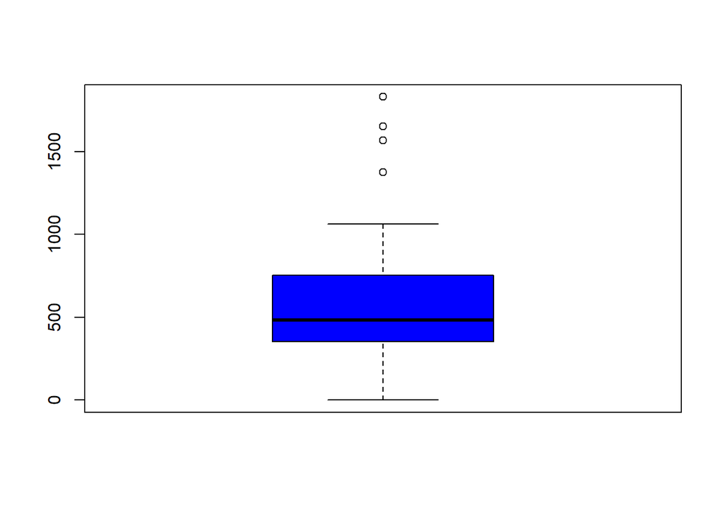

```r
boxplot(Tuition_Assistance1$Cost, col= "blue")
```

```r
summary(Tuition_Assistance1$Cost)
```

```
##    Min. 1st Qu.  Median    Mean 3rd Qu.    Max.
##     0.0   354.0   483.3   623.1   753.0  1830.0
```

## Visualization with ggplot

```r
g<-ggplot(data = Tuition_Assistance1, mapping = aes(x = Cost, y = Degree))
```

```r
class(g)
```

```
## [1] "gg"     "ggplot"
```

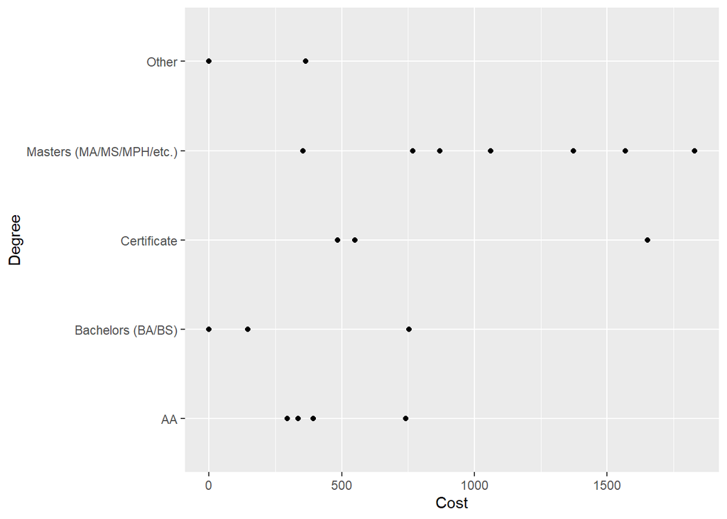

```r
g + geom_point()
```

## t test

### Formulate your question in terms of t-test

Is the difference of means significant?

### Choose a categorical variable to create the two samples

```r
df1<-subset(Tuition_Assistance1, Degree == "Bachelors (BA/BS)")
df2<-subset(Tuition_Assistance1, Degree == "AA")
```

#### Justify why you reject or fail to reject the Null hypothesis based on p-value and confidence interval

```r
t.test(df1$Cost, df2$Cost)
```

```
##
##  Welch Two Sample t-test
##
## data:  df1$Cost and df2$Cost
## t = 0.103, df = 3.3317, p-value = 0.9239
## alternative hypothesis: true difference in means is not equal to 0
## 95 percent confidence interval:
##  -592.7799  634.7799
## sample estimates:
## mean of x mean of y
##       413       392
```

p-value = 0.9239 > 0.05 then we fail to reject the Null hypothesis. Also, t value which is 0.103 belongs to the confidence interval: -592.7799 634.7799.